# ep09-hooks-in-claude-code

Claude Code 101 系列教程 · 第 9 课

Claude (Anthropic)

2026-05-20

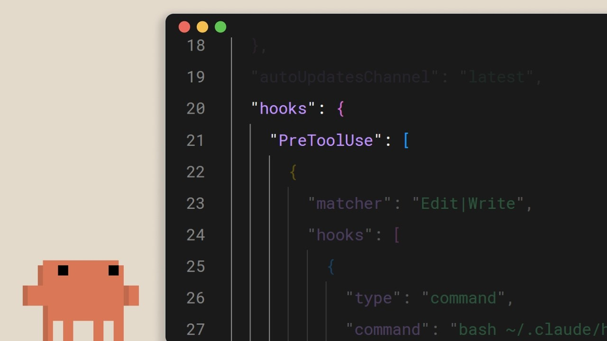

第 9 课 · Hooks in Claude Code

# Hooks in Claude Code

*Claude Code 101 系列教程 · 第 9 课 · 来自 [Claude 官方频道](https://www.youtube.com/@claude)*

## 什么是 Hooks？

Hooks 让你在 Claude Code 生命周期的关键节点上运行**自定义命令**——提供**确定性控制**，确保某些操作**始终发生**，而不是依赖 LLM 来选择是否执行。

> **关键区别：** CLAUDE.md 里的指令是**建议性的**（Claude 可能不遵守），而 Hooks 是**确定性的**（每次都会执行）。

## Hook 的五种类型

| 类型 | 工作方式 | 适合场景 |
| --- | --- | --- |
| `command` | 运行 Shell 命令 | 格式化、拦截、通知 |
| `http` | POST 到一个 URL | 外部服务、审计日志 |
| `mcp_tool` | 调用 MCP Server 上的工具 | MCP 集成 |
| `prompt` | 单轮 LLM 评估 | 需要判断力的决策 |
| `agent` | 多轮子代理（实验性） | 需要文件检查的验证 |

## 生命周期事件

Hooks 在以下时刻触发：

### 每个工具调用

| 事件 | 时机 | 能否拦截 |
| --- | --- | --- |
| `PreToolUse` | 工具执行**之前** | 可以阻止 |
| `PostToolUse` | 工具执行**之后** | 可以添加反馈 |

### 每轮对话

| 事件 | 时机 |
| --- | --- |
| `UserPromptSubmit` | 用户提交 Prompt 时 |
| `Stop` | Claude 完成响应时 |

### 会话级

| 事件 | 时机 |
| --- | --- |
| `SessionStart` | 会话开始时 |
| `Notification` | Claude 发送通知时 |

## 配置位置

Hooks 定义在 **settings.json** 中，有三个位置：

| 位置 | 作用范围 |
| --- | --- |
| `.claude/settings.json`（项目根目录） | 当前项目，可提交到版本控制 |
| `.claude/settings.local.json` | 当前项目，不提交 |
| `~/.claude/settings.json` | 所有项目，个人偏好 |

## 实战示例

### 1. 编辑后自动格式化

每次 Claude 编辑文件后，自动运行 Prettier：

```json
{
  "hooks": {
    "PostToolUse": [
      {
        "matcher": "Edit|Write",
        "hooks": [
          {
            "type": "command",
            "command": "jq -r '.tool_input.file_path' | xargs npx prettier --write"
          }
        ]
      }
    ]
  }
}
```

### 2. 阻止危险操作

阻止 `rm -rf` 和保护敏感文件。

**脚本 `.claude/hooks/protect-files.sh`：**

```bash
#!/bin/bash
INPUT=$(cat)
FILE_PATH=$(echo "$INPUT" | jq -r '.tool_input.file_path // empty')
COMMAND=$(echo "$INPUT" | jq -r '.tool_input.command // empty')

# 阻止 rm -rf
if echo "$COMMAND" | grep -q 'rm -rf'; then
  echo "Blocked: rm -rf is not allowed" >&2
  exit 2
fi

# 保护敏感文件
for pattern in ".env" "package-lock.json" ".git/"; do
  if [[ "$FILE_PATH" == *"$pattern"* ]]; then
    echo "Blocked: $FILE_PATH matches protected pattern" >&2
    exit 2
  fi
done
exit 0
```

```bash
chmod +x .claude/hooks/protect-files.sh
```

**配置：**

```json
{
  "hooks": {
    "PreToolUse": [
      {
        "matcher": "Edit|Write",
        "hooks": [
          {
            "type": "command",
            "command": "${CLAUDE_PROJECT_DIR}/.claude/hooks/protect-files.sh"
          }
        ]
      },
      {
        "matcher": "Bash",
        "hooks": [
          {
            "type": "command",
            "if": "Bash(rm *)",
            "command": "${CLAUDE_PROJECT_DIR}/.claude/hooks/protect-files.sh"
          }
        ]
      }
    ]
  }
}
```

### 3. Claude 需要输入时发送通知

在 macOS 上弹出桌面通知：

```json
{
  "hooks": {
    "Notification": [
      {
        "hooks": [
          {
            "type": "command",
            "command": "osascript -e 'display notification \"Claude Code needs your attention\" with title \"Claude Code\"'"
          }
        ]
      }
    ]
  }
}
```

## Matcher 和 if 过滤

### Matcher — 按工具名过滤

| Matcher 值 | 含义 |
| --- | --- |
| 省略或 `"*"` | 匹配所有 |
| `"Edit"` | 仅匹配 Edit 工具 |
| `"Edit\\|Write"` | 匹配 Edit 或 Write |

### if — 按权限规则语法过滤

更精细的条件控制，只匹配特定命令模式：

```json
{
  "type": "command",
  "if": "Bash(git push *)",
  "command": "./check-git-policy.sh"
}
```

## 退出码的含义

| 退出码 | 行为 |
| --- | --- |
| `0` | 正常，继续执行 |
| `2` | 阻止操作（PreToolUse 时阻止工具执行） |
| 其他 | 错误，反馈给 Claude |

## 最佳实践

- **从简单开始** — 先加一个 `PostToolUse` 做格式化，再逐步添加拦截逻辑
- **用 `if` 减少不必要的进程** — 比在脚本内部检查命令更高效
- **保持 Hook 快速** — 每个工具调用都会触发，太慢会增加延迟
- **长任务用 `async: true`** — 测试套件等耗时操作设为异步，Claude 继续工作
- **用 `/hooks` 验证配置** — 在 Claude Code 内运行查看所有已配置的 Hooks
- **使用绝对路径** — 用 `${CLAUDE_PROJECT_DIR}` 确保脚本路径正确

## 总结

- **Hooks** = Claude Code 生命周期的确定性自动化
- **PreToolUse** — 工具执行前拦截（如阻止危险操作）
- **PostToolUse** — 工具执行后处理（如自动格式化）
- **退出码 0 = 通过，2 = 阻止**
- **与 CLAUDE.md 的区别**：CLAUDE.md 是建议，Hooks 是硬规则
- **从简单开始**，逐步增加复杂度

*本教程基于 Claude 官方视频 [Hooks in Claude Code](https://www.youtube.com/watch?v=IkaPHiMDazM) 整理，属于 Claude Code 101 系列第 9 课。*